# HEART DISEASE PREDICTIONS (LOGISTIC REGRESSION MODEL)

# Step 12: Visualize model predictions

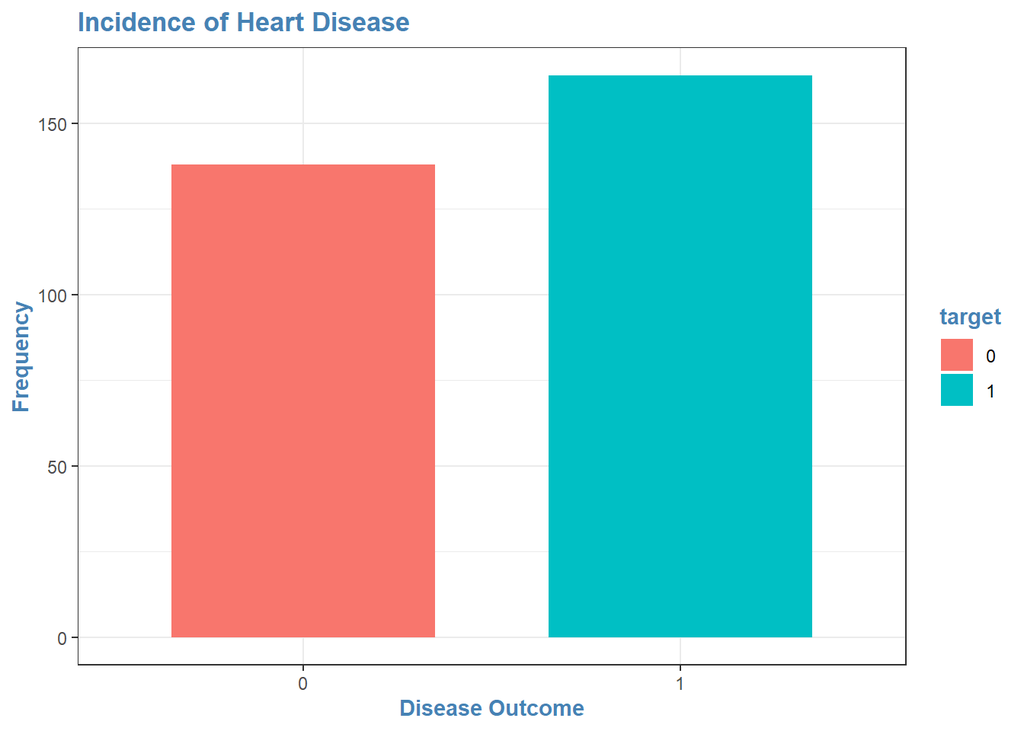

```r
# A. Overall Incidence of Heart Disease
theme_set(theme_bw()+theme(title = element_text
                           (face = "bold",
                             colour = "steelblue")))
ggplot(heart, aes(target, fill = target))+
  geom_bar(width = 0.7)+
  labs(title = "Incidence of Heart Disease",
       y = "Frequency",
       x = "Disease Outcome")
```

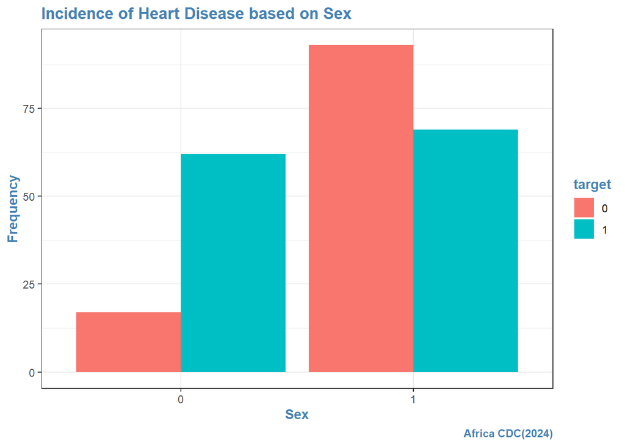

```r
# B. Incidence of Heart Disease based on Sex
ggplot(training, aes(sex, fill = target))+
  geom_bar(position = "dodge")+
  labs(title = "Incidence of Heart Disease based on Sex",
       y = "Frequency",
       x = "Sex",
       caption = "Africa CDC(2024)")
```

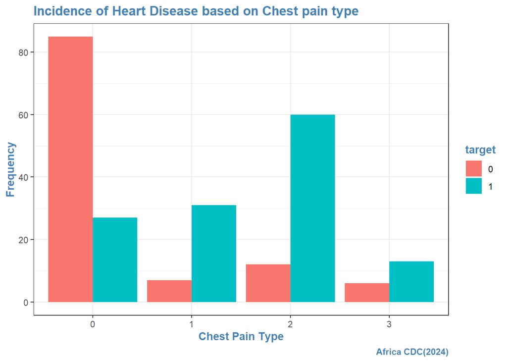

```r
# C. Incidence of Heart Disease based on Chest pain type
ggplot(training, aes(cp, fill = target))+
  geom_bar(position = "dodge")+
  labs(title = "Incidence of Heart Disease based on Chest pain type",
       y = "Frequency",
       x = "Chest Pain Type",
       caption = "Africa CDC(2024)")
```

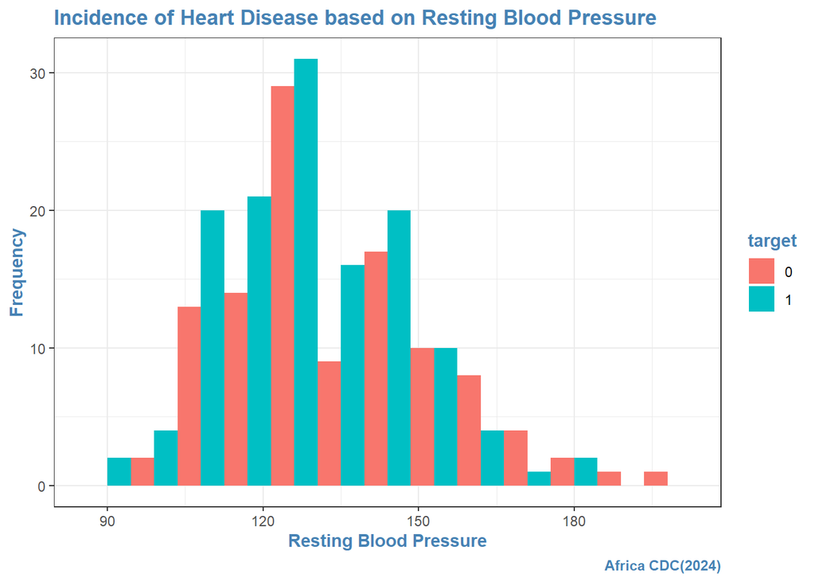

```r
# D. Incidence of Heart Disease based on Resting Blood Pressure
ggplot(training, aes(trestbps, fill = target))+
  geom_histogram(binwidth = 9, position = "dodge")+
  labs(title = "Incidence of Heart Disease based on Resting Blood Pressure",
       y = "Frequency",
       x = "Resting Blood Pressure",
       caption = "Africa CDC(2024)")
```

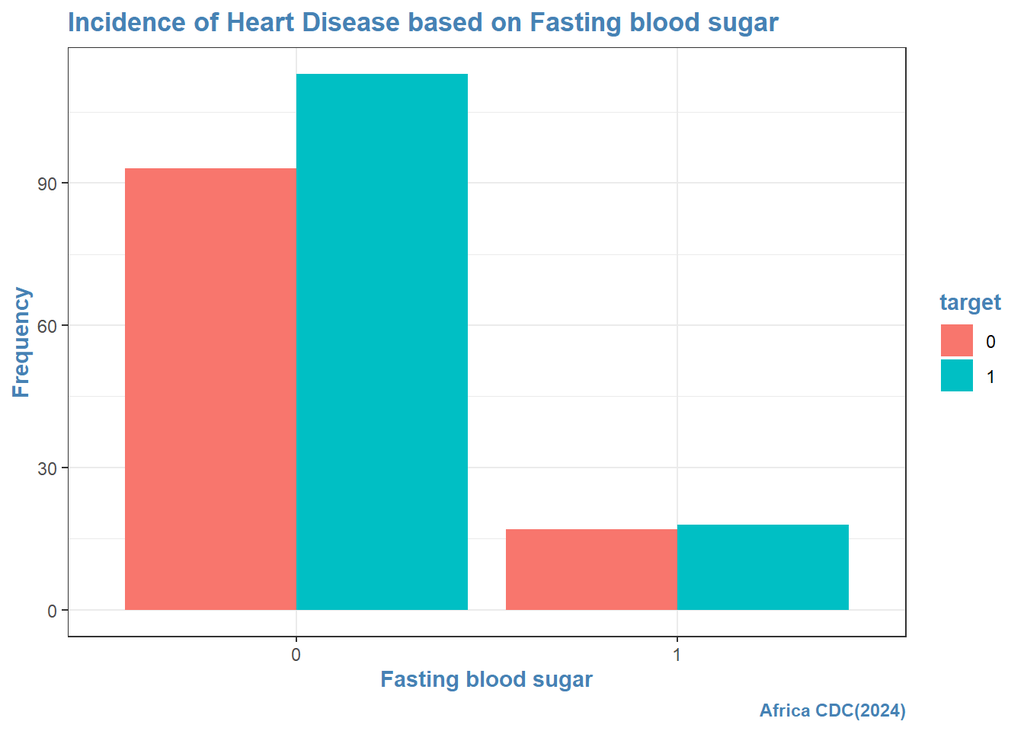

```r
# E. Incidence of Heart Disease based on Fasting blood sugar
ggplot(training, aes(fbs, fill = target))+
  geom_bar(position = "dodge")+
  labs(title = "Incidence of Heart Disease based on Fasting blood sugar",
       y = "Frequency",
       x = "Fasting blood sugar",
       caption = "Africa CDC(2024)")
```

```r
table(heart$target, heart$fbs)
```

```
##
##       0   1
##   0 116  22
##   1 141  23
```

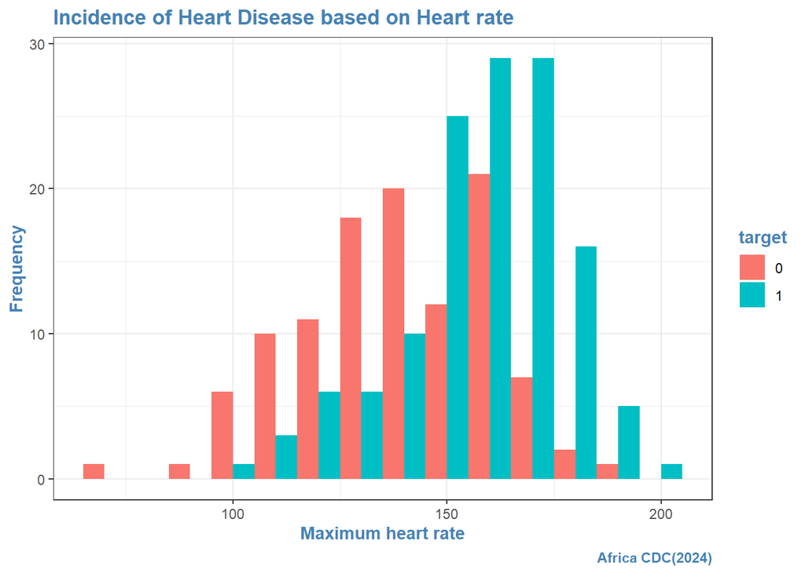

```r
# F. Incidence of Heart Disease based on Heart rate
ggplot(training, aes(thalach, fill = target))+
  geom_histogram(binwidth = 10, position = "dodge")+
  labs(title = "Incidence of Heart Disease based on Heart rate",
       y = "Frequency",
       x = "Maximum heart rate",
       caption = "Africa CDC(2024)")
```

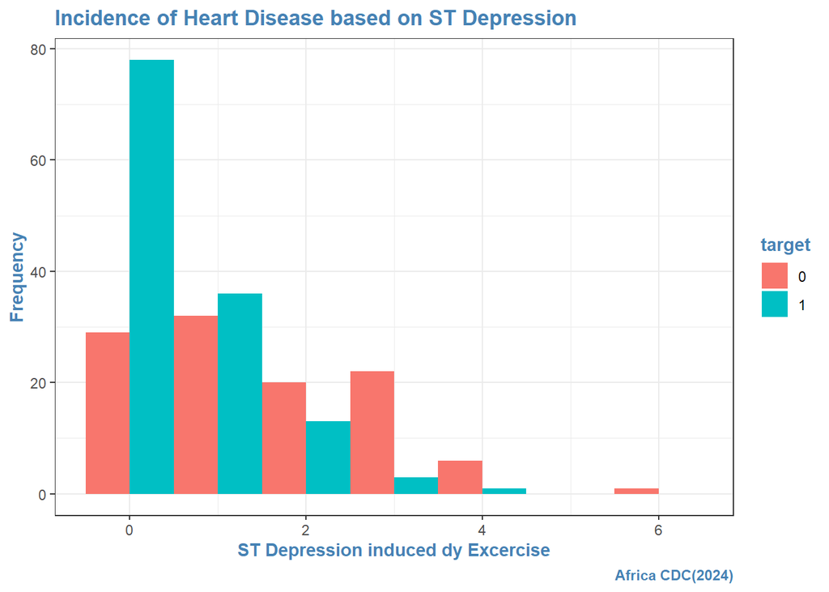

```r
# G. Incidence of Heart Disease based on ST Depression
ggplot(training, aes(oldpeak, fill = target))+
  geom_histogram(binwidth = 1, position = "dodge")+
  labs(title = "Incidence of Heart Disease based on ST Depression",
       y = "Frequency",
       x = "ST Depression induced dy Excercise",
       caption = "Africa CDC(2024)")
```

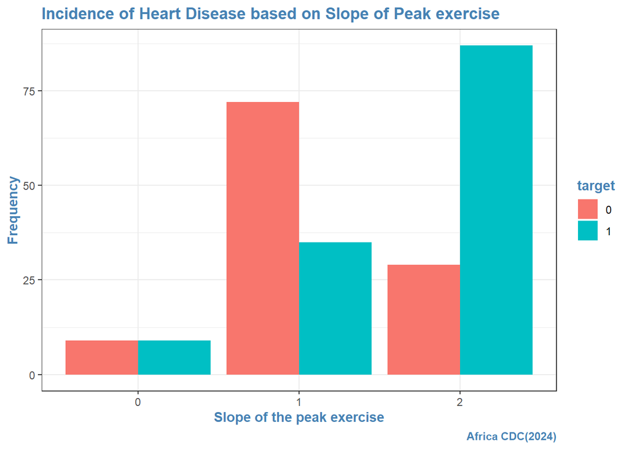

```r
# H. Incidence of Heart Disease based on Slope of Peak exercise
ggplot(training, aes(slope, fill = target))+
  geom_bar(position = "dodge")+
  labs(title = "Incidence of Heart Disease based on Slope of Peak exercise",
       y = "Frequency",
       x = "Slope of the peak exercise",
       caption = "Africa CDC(2024)")
```

```r
table(heart$target, heart$slope)
```

```
##
##       0   1   2
##   0  12  91  35
##   1   9  49 106
```

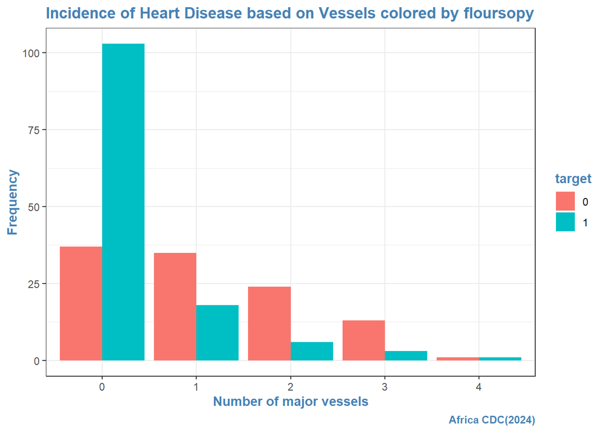

```r
# I. Incidence of Heart Disease based on Vessels colored by floursopy
ggplot(training, aes(ca, fill = target))+
  geom_bar(position = "dodge")+
  labs(title = "Incidence of Heart Disease based on Vessels colored by floursopy",
       y = "Frequency",
       x = "Number of major vessels",
       caption = "Africa CDC(2024)")
```

```r
table(heart$target, heart$ca)
```

```
##
##       0   1   2   3   4
##   0  45  44  31  17   1
##   1 130  21   7   3   3
```

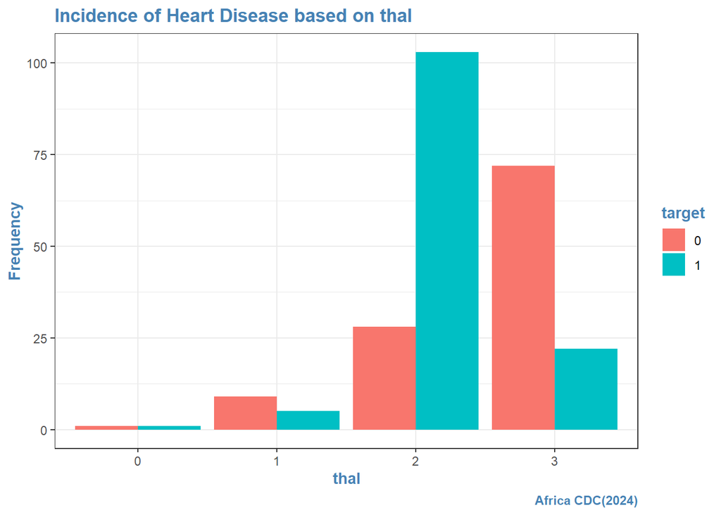

```r
# J. Incidence of Heart Disease based on thal
ggplot(training, aes(thal, fill = target))+
  geom_bar(position = "dodge")+
  labs(title = "Incidence of Heart Disease based on thal",
       y = "Frequency",
       caption = "Africa CDC(2024)")
```

# Step 13: Check Model Performance

```r
# Produce model equation
#install.packages("equatiomatic")
library(equatiomatic)
extract_eq(model)
```

$$\log\left[ \frac { P( \operatorname{target} = \operatorname{1} ) }{ 1 -
P( \operatorname{target} = \operatorname{1} ) } \right] = \alpha +
\beta_{1}(\operatorname{sex}_{\operatorname{1}}) +
\beta_{2}(\operatorname{cp}_{\operatorname{1}}) +
\beta_{3}(\operatorname{cp}_{\operatorname{2}}) +
\beta_{4}(\operatorname{cp}_{\operatorname{3}}) +
\beta_{5}(\operatorname{trestbps}) +
\beta_{6}(\operatorname{fbs}_{\operatorname{1}}) +
\beta_{7}(\operatorname{thalach}) + \beta_{8}(\operatorname{oldpeak}) +
\beta_{9}(\operatorname{slope}_{\operatorname{1}}) +
\beta_{10}(\operatorname{slope}_{\operatorname{2}}) +
\beta_{11}(\operatorname{ca}_{\operatorname{1}}) +
\beta_{12}(\operatorname{ca}_{\operatorname{2}}) +
\beta_{13}(\operatorname{ca}_{\operatorname{3}}) +
\beta_{14}(\operatorname{ca}_{\operatorname{4}}) +
\beta_{15}(\operatorname{thal}_{\operatorname{1}}) +
\beta_{16}(\operatorname{thal}_{\operatorname{2}}) +
\beta_{17}(\operatorname{thal}_{\operatorname{3}})$$

```r
#How well our model fits the data
library(performance)
performance(model)
```

```
## # Indices of model performance
##
## AIC     |    AICc |     BIC | Tjur's R2 |  RMSE | Sigma | Log_loss | Score_log
## ------------------------------------------------------------------------------
## 166.193 | 169.274 | 228.920 |     0.665 | 0.287 | 1.000 |    0.270 |      -Inf
##
## AIC     | Score_spherical |   PCP
## ---------------------------------
## 166.193 |           0.025 | 0.834
```

```r
library(effectsize)
interpret_r2(0.665)
```

```
## [1] "substantial"
## (Rules: cohen1988)
```

# Step 14: Visualize the distribution of risk categories

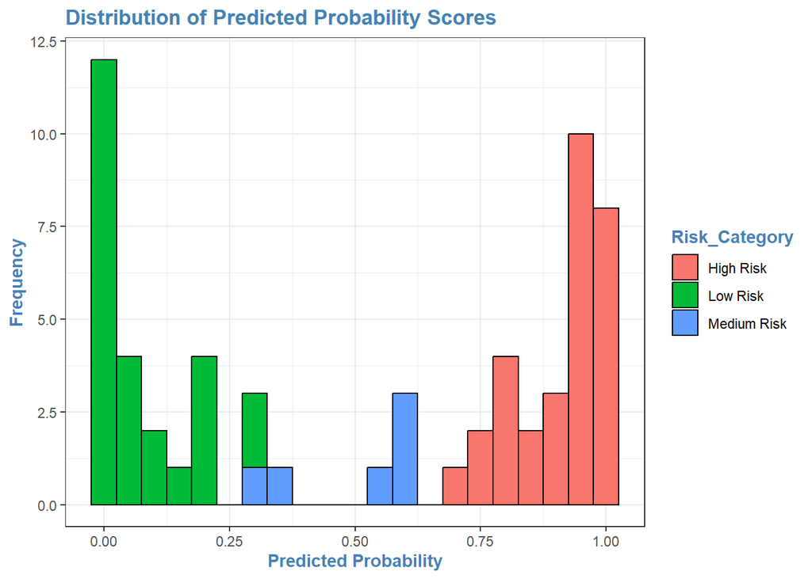

```r
#Generate model probabilities
probs <- predict(model, testing, type = "response")
#Data frame with actual target and predicted probabilities
scores <- data.frame(
  Actual = testing$target,
  Predicted_Probability = probs
  )

# Classify the scores into risk categories
# Define risk categories based on probability thresholds
library(dplyr)
scores <- scores %>%
  mutate(
    Risk_Category = case_when(
      Predicted_Probability < 0.3 ~ "Low Risk",
      Predicted_Probability >= 0.3 & Predicted_Probability < 0.6 ~ "Medium Risk",
      Predicted_Probability >= 0.6 ~ "High Risk"
      )
    )

# Visualize the distribution of risk categories
library(ggplot2)
ggplot(scores, aes(x = Predicted_Probability, fill = Risk_Category)) +
  geom_histogram(binwidth = 0.05, color = "black") +
  labs(title = "Distribution of Predicted Probability Scores",
       x = "Predicted Probability",
       y = "Frequency")
```

```r
# Review the first few rows of the score data
head(scores, 30)
```

```
##    Actual Predicted_Probability Risk_Category
## 1       0          0.1936875725      Low Risk
## 2       0          0.0934782022      Low Risk
## 3       0          0.2997032177      Low Risk
## 4       0          0.9294019274     High Risk
## 5       0          0.8761094468     High Risk
## 6       1          0.0028066440      Low Risk
## 7       0          0.1435069905      Low Risk
## 8       1          0.8063566989     High Risk
## 9       1          0.9472678160     High Risk
## 10      0          0.0036480026      Low Risk
## 11      1          0.5850682700   Medium Risk
## 12      0          0.1976715032      Low Risk
## 13      0          0.0132086376      Low Risk
## 14      1          0.9759977332     High Risk
```

[output cut: 16 more lines]

```r
print(scores)
```

```
##    Actual Predicted_Probability Risk_Category
## 1       0          0.1936875725      Low Risk
## 2       0          0.0934782022      Low Risk
## 3       0          0.2997032177      Low Risk
## 4       0          0.9294019274     High Risk
## 5       0          0.8761094468     High Risk
## 6       1          0.0028066440      Low Risk
## 7       0          0.1435069905      Low Risk
## 8       1          0.8063566989     High Risk
## 9       1          0.9472678160     High Risk
## 10      0          0.0036480026      Low Risk
## 11      1          0.5850682700   Medium Risk
## 12      0          0.1976715032      Low Risk
## 13      0          0.0132086376      Low Risk
## 14      1          0.9759977332     High Risk
```

[output cut: 47 more lines]

# Interpretation:

B. Accuracy 1. The model correctly predicts about 82% of cases, which indicates it performs well overall. 2. However, accuracy alone may not be sufficient if the cost of false positives or false negatives is high.

E. F1-Score 1. The F1-Score balances Precision and Recall. 2. An F1-Score of 84% indicates the model has a good trade-off between catching most cases (high recall) and being accurate in its predictions (precision).

2. Interpretation of ROC Curve: 2.1 The curve rising steeply towards the top-left corner indicates high sensitivity and specificity for various thresholds. 2.2 Adjusting thresholds can optimize for precision or recall based on application needs

G. Risk Categorization 1. Categorizing patients into risk levels based on predicted probabilities: 2. Low Risk (< 30%): Patients unlikely to have heart disease. 3. Medium Risk (30–60%): Patients with a moderate likelihood of heart disease. 4. High Risk (> 60%): Patients with a high likelihood of heart disease.

Interpretation: 1. This segmentation helps prioritize patients for further tests or interventions. 2. For instance, “High Risk” patients might need immediate attention, while “Low Risk” patients can be monitored.

H. Key Takeaways 1. The model performs well overall, as shown by high accuracy, recall, and AUC. 2. Strength: High recall ensures most patients with heart disease are identified. 3. Limitation: Some false positives (FP) and false negatives (FN) remain, which can have implications in a clinical setting